# DAB300 - FINAL PROJECT - STOCK MARKET PRICE PREDICTION

#### GROUP NUMBER: 17

- Meghaben - W0749147
- Vipin - W0755900
- Yasmin - W0754285
- Urmi - W0756341
- Trang Bui- W0753523

### Dataset

The dataset and its detail description can be found under the following URL: https://www.kaggle.com/rpaguirre/tesla-stock-price  
Dataset description is described from the owner as below

- The Tesla stock price details are from the initial public offering from 06/29/2010 to 03/17/2017 (1692 data rows), also originally taken from the yahoo financing
- Attributes:  
  o Date - the date  
  o Open – the stock's opening price  
  o High – for That day's high price  
  o Low – for That day's low price  
  o Close – for the closing price of the day  
  o Volume – as of the sum of stocks exchanged in the day (the number of shares passed from one onwner to another in the day).  
  o Adj Close – indicates the closing price of the stock that has been changed to include any distributions / corporate actions that occur before opening the next day.

Moreover, for model evaluation, we used 10 other stock datasets. These datasets are derived from the original file containing 140 stocks from 2010 to end of 2016 downloaded from Kaggle (URL: https://www.kaggle.com/dgawlik/nyse?select=prices.csv).  
This is the list of 10 stocks used for model evaluation: AAP, AAL, AAPL, BAC, BAX, BA, CA, CAH, CAG, DAL

### Import libraries

```python
# Import the appropriate Libraries
import warnings
warnings.filterwarnings('ignore')
import time
import os, sys
from datetime import datetime, date

import numpy as np
import pandas as pd # for dataframes

#pip install pandas_datareader
from pandas_datareader.data import DataReader

from tensorflow.keras.models import Sequential
from tensorflow.keras.layers import Dense, Dropout, LSTM, Flatten, MaxPooling2D, Activation, BatchNormalization

from sklearn.preprocessing import LabelEncoder
from sklearn.preprocessing import MinMaxScaler
from sklearn.model_selection import train_test_split, GridSearchCV

# Evaluating the results and validate accuracy
from sklearn import metrics
from sklearn.metrics import accuracy_score,precision_score,recall_score,f1_score
from sklearn.metrics import classification_report
from sklearn.metrics import mean_squared_error, mean_squared_log_error, r2_score

from sklearn.svm import SVR
from statsmodels.tsa.arima_model import ARIMA

import matplotlib.pyplot as plt # for plotting graphs
import seaborn as sns # for plotting graphs
import plotly.graph_objs as go #visualization
import plotly.offline as py#visualization
```

### Data Import

```python
print('++++++++++ LOAD DATA +++++++++')
def fn_load_data(realtime=0, p_stockName='TSLA', p_year=2):
    if (realtime==1):
        # Read data online from remote source
        enddate = datetime.now()
        startdate = datetime(enddate.year - p_year, enddate.month, enddate.day)
        data_raw=DataReader(p_stockName, 'yahoo', startdate, enddate)
    else:
        data_raw = pd.read_csv('Tesla.csv', encoding= 'ISO-8859-1', index_col='Date', parse_dates=['Date'])
    # make a copy dataframe for working
    data=data_raw.copy()
    return data, data_raw

p_realtime=0
p_stockname='TSLA'
p_year=2
data, data_raw = fn_load_data(p_realtime,p_stockname,p_year)
print("Raw Data.shape:",data.shape)

print("Raw Data.info:")
print(data.info())
```

```
++++++++++ LOAD DATA +++++++++
Raw Data.shape: (1692, 6)
Raw Data.info:
<class 'pandas.core.frame.DataFrame'>
DatetimeIndex: 1692 entries, 2010-06-29 to 2017-03-17
Data columns (total 6 columns):
 #   Column     Non-Null Count  Dtype
---  ------     --------------  -----
 0   Open       1692 non-null   float64
 1   High       1692 non-null   float64
 2   Low        1692 non-null   float64
 3   Close      1692 non-null   float64
 4   Volume     1692 non-null   int64
 5   Adj Close  1692 non-null   float64
dtypes: float64(5), int64(1)
memory usage: 92.5 KB
None
```

### Data Pre-processing

```python
def sniff_modified(df):
    with pd.option_context("display.max_colwidth", 100):
        info = pd.DataFrame()
        info['data type'] = df.dtypes
        info['percent missing'] = df.isnull().sum()*100/len(df)
        info['nb of unique'] = df.apply(lambda x: len(x.unique()))
        info['unique values'] =  df.T.apply(lambda x: x.unique(), axis=1)
        return info.sort_values('data type')

def fn_check_missing_data_cols(data):
    df_info = sniff_modified(data)
    pd.set_option('display.max_rows', None)
    nb_missing_cols = len(df_info[df_info['percent missing']>0])
    if (nb_missing_cols ==0):
        print('There is no missing data cols in the dataset')
    return df_info, nb_missing_cols

data = data_raw.copy()

data_missing_info, nb_missing_cols = fn_check_missing_data_cols(data)

if (nb_missing_cols>0):
    print("Missing Data.info:")
    print(data_missing_info.info())

# print("Drop unneccesary column ""Adj Close""")
# data=data.drop(['Adj Close'],axis=1)

# rearrage columns to move target to end
data=data[['High','Low','Open','Volume','Adj Close','Close']]

print("Data.info [After Preprocessing]:")
print(data.info())

data.head()
```

```
There is no missing data cols in the dataset
Data.info [After Preprocessing]:
<class 'pandas.core.frame.DataFrame'>
DatetimeIndex: 1692 entries, 2010-06-29 to 2017-03-17
Data columns (total 6 columns):
 #   Column     Non-Null Count  Dtype
---  ------     --------------  -----
 0   High       1692 non-null   float64
 1   Low        1692 non-null   float64
 2   Open       1692 non-null   float64
 3   Volume     1692 non-null   int64
 4   Adj Close  1692 non-null   float64
 5   Close      1692 non-null   float64
dtypes: float64(5), int64(1)
memory usage: 92.5 KB
None
```

| Date | High | Low | Open | Volume | Adj Close | Close |
| --- | --- | --- | --- | --- | --- | --- |
| 2010-06-29 | 25.00 | 17.540001 | 19.000000 | 18766300 | 23.889999 | 23.889999 |
| 2010-06-30 | 30.42 | 23.299999 | 25.790001 | 17187100 | 23.830000 | 23.830000 |
| 2010-07-01 | 25.92 | 20.270000 | 25.000000 | 8218800 | 21.959999 | 21.959999 |
| 2010-07-02 | 23.10 | 18.709999 | 23.000000 | 5139800 | 19.200001 | 19.200001 |
| 2010-07-06 | 20.00 | 15.830000 | 20.000000 | 6866900 | 16.110001 | 16.110001 |

```python
data.describe()
```

|  | High | Low | Open | Volume | Adj Close | Close |
| --- | --- | --- | --- | --- | --- | --- |
| count | 1692.000000 | 1692.000000 | 1692.000000 | 1.692000e+03 | 1692.000000 | 1692.000000 |
| mean | 134.769698 | 129.996223 | 132.441572 | 4.270741e+06 | 132.428658 | 132.428658 |
| std | 95.694914 | 92.855227 | 94.309923 | 4.295971e+06 | 94.313187 | 94.313187 |
| min | 16.629999 | 14.980000 | 16.139999 | 1.185000e+05 | 15.800000 | 15.800000 |
| 25% | 30.650000 | 29.215000 | 30.000000 | 1.194350e+06 | 29.884999 | 29.884999 |
| 50% | 162.370002 | 153.150002 | 156.334999 | 3.180700e+06 | 158.160004 | 158.160004 |
| 75% | 224.099999 | 217.119999 | 220.557495 | 5.662100e+06 | 220.022503 | 220.022503 |
| max | 291.420013 | 280.399994 | 287.670013 | 3.716390e+07 | 286.040009 | 286.040009 |

### Data visualization and exploration

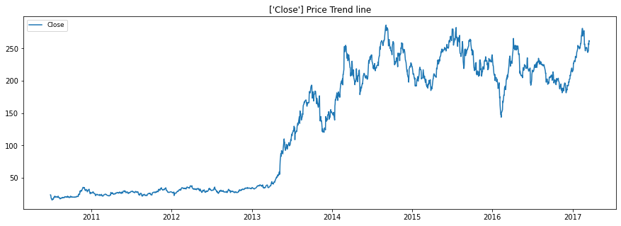

```python
def fn_lineplot(df,p_title,p_xlabel,p_ylabel,p_dfplot,p_nb_cols):
    p_width=15
    p_hight=5
    fig,ax=plt.subplots(1,figsize=(p_width,p_hight))

    for column in df.columns:
        ax.plot(df[column],label=column)

    ax.set_xlabel= p_xlabel
    ax.set_ylabel= p_ylabel
    ax.set_title(p_title, fontsize=12)
    ax.legend(loc='best', fontsize=9)

p_nb_cols=1
p_cols = ['Close']
p_dfplot = data[p_cols]
p_title= str(p_cols) + ' Price Trend line'
p_xlabel='Date'
p_ylabel='Price'
fn_lineplot(p_dfplot,p_title=p_title,p_xlabel=p_xlabel,p_ylabel=p_ylabel,p_dfplot=p_dfplot,p_nb_cols=p_nb_cols)
```

```
array([[<AxesSubplot:title={'center':'Close'}>]], dtype=object)
```

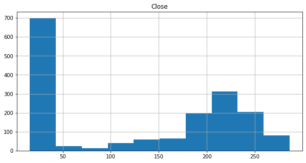

```python
# Using histograms to check data distribution of category cols
data.hist(column=p_cols,grid=True,figsize=(10,5),bins=10)
```

### Build models

#### Define Common Functions

```python
def fn_scale_data(df):
    scaler = MinMaxScaler(feature_range=(0,1)) #desired range of transformed data between [0,1]
    df_scaled = scaler.fit_transform(df)
    return df_scaled, scaler

def fn_split_data(p_X, p_Y, p_pct_train, p_pct_val):
    # p_pct_train is the percentage of train set. Example: p_pct_train=0.7
    # p_pct_val is the percentage of val set. Example: p_pct_val=0.1
    # test set is the remain

    nb_observation = p_X.shape[0]
    stop_point_train = int(np.floor(p_pct_train*nb_observation))
    stop_point_val = int(np.floor((p_pct_train+p_pct_val)*nb_observation))

    x_train=p_X[0:stop_point_train]
    y_train=p_Y[0:stop_point_train]

    x_val=p_X[stop_point_train:stop_point_val]
    y_val=p_Y[stop_point_train:stop_point_val]

    x_test=p_X[stop_point_val:]
    y_test=p_Y[stop_point_val:]

    return x_train, y_train, x_val, y_val, x_test, y_test


def fn_build_data_XY(df, p_look_back, p_predict_day):
    # For time-series problem, input variables for training usually include date series and features that are used for looking back and learning the trend of history
    print('1. Build X and y dataset that are input and target Variables')
    print('----------X dataset has sequences of date that is date series and all features')
    print('----------Y dataset has sequences of date that is date series and the feature "CLOSE"')
    print('----------The number of recent days to look back in order to predict the next day:', p_look_back)
    print('----------The number of predict day:', p_predict_day)
    X, Y = [], []
    nloop = (df.shape[0])-(p_look_back)-(p_predict_day)
    for i in range(nloop):
        X.append(np.array(df[i:i+p_look_back]))
        Y.append(np.array(df[i+p_look_back:i+p_look_back+ p_predict_day,-1:])) # (-1) is to get the last column that is column CLose (target column)
    return np.array(X), np.array(Y)


def fn_plotaccdf(p_df, p_kind):
#    print("*******************************************************************************************************************")
#    print("                               Test Accuracy of all Models                                                ")
#    print("*******************************************************************************************************************")
    p_df.plot(kind = p_kind)
    plt.xlabel('Models')
    plt.ylabel('Accuracy')
    plt.title('Test Accuracy of all Models')
    plt.legend(loc = 0)
    plt.show()
    return

def fn_init():
    n_pct_train= 0.7
    n_pct_val= 0.1

    df_acc = pd.DataFrame()
    df_loss = pd.DataFrame()

    return n_pct_train, n_pct_val
```

```python
# Reset data frame to store accuracy information
df_score = pd.DataFrame()
```

#### Persistence Model

```
================================================================================================================================
=                                                  PERSISTENCE                                                                 =
================================================================================================================================
data.shape: (1692, 6)
x_train.shape: (1184,) y_train.shape:  (1184,)
x_test.shape: (339,) y_test.shape:  (339,)
x_val.shape: (169,) y_val.shape:  (169,)
Validation mean squared error of  Persistence  model: 21.864
Test mean squared error of  Persistence  model: 20.220
```

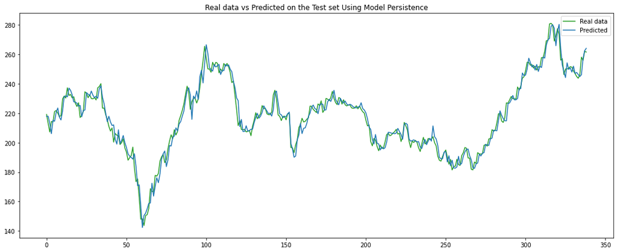

```python
def fn_persistence(data):
    print('================================================================================================================================')
    print('=                                                  PERSISTENCE                                                                 =')
    print('================================================================================================================================')

    n_pct_train,n_pct_val= fn_init()

    X=data['Open'].values
    Y=data['Close'].values

    x_train, y_train, x_val, y_val, x_test, y_test=fn_split_data(p_X=X, p_Y=Y, p_pct_train=n_pct_train, p_pct_val=n_pct_val)
    print('data.shape:',data.shape)
    print('x_train.shape:',x_train.shape, 'y_train.shape: ',y_train.shape)
    print('x_test.shape:',x_test.shape, 'y_test.shape: ',y_test.shape)
    print('x_val.shape:',x_val.shape, 'y_val.shape: ', y_val.shape)

    # define persistence model
    p_modelname='Persistence'
    def model_persistence(x):
        return x

    # validate
    y_pred = list()
    for x in x_val:
        y_pred.append(model_persistence(x))

    val_score = mean_squared_error(y_val, y_pred)
    print('Validation mean squared error of ',p_modelname,' model: %.3f' % val_score)

    # Test dataset
    y_pred = list()
    for x in x_test:
        y_pred.append(model_persistence(x))

    test_score = mean_squared_error(y_test, y_pred)
    print('Test mean squared error of ',p_modelname,' model: %.3f' % test_score)


    plt.figure(figsize = (18,7))
    plt.title('Real data vs Predicted on the Test set Using Model '+p_modelname)
    plt.plot(y_test, 'tab:green', label='Real data')
    plt.plot(y_pred, 'tab:blue', label='Predicted')
    plt.legend()
    plt.show()
    return test_score

test_score=fn_persistence(data)

# store to compare with other models
result={'model':['Persistence'],'test_score':[test_score]}
df_score=df_score.append(pd.DataFrame(result),ignore_index=True)
```

#### LSTM Model

```
================================================================================================================================
=                                                  LSTM MODEL                                                                  =
================================================================================================================================
1. Build X and y dataset that are input and target Variables
----------X dataset has sequences of date that is date series and all features
----------Y dataset has sequences of date that is date series and the feature "CLOSE"
----------The number of recent days to look back in order to predict the next day: 7
----------The number of predict day: 1
data.shape: (1692, 6)
x_train.shape: (1178, 7, 6) y_train.shape:  (1178, 1, 1)
x_test.shape: (337, 7, 6) y_test.shape:  (337, 1, 1)
x_val.shape: (169, 7, 6) y_val.shape:  (169, 1, 1)
2. BUILD LSTM MODEL
----------Optimizer: adam
----------Activation:  sigmoid
----------Input shape:  (7, 6)
----------Loss:  mean_squared_error
3. MODEL TRAINING :  LSTM
10/10 - 1s - loss: 0.5259 - val_loss: 0.1256
10/10 - 0s - loss: 0.1885 - val_loss: 0.3599
10/10 - 0s - loss: 0.1173 - val_loss: 0.3420
10/10 - 0s - loss: 0.0832 - val_loss: 0.2222
10/10 - 0s - loss: 0.0736 - val_loss: 0.1482
10/10 - 0s - loss: 0.0714 - val_loss: 0.1247
10/10 - 0s - loss: 0.0624 - val_loss: 0.1181
10/10 - 0s - loss: 0.0507 - val_loss: 0.1056
10/10 - 0s - loss: 0.0408 - val_loss: 0.0861
10/10 - 0s - loss: 0.0334 - val_loss: 0.0681
10/10 - 0s - loss: 0.0275 - val_loss: 0.0547
10/10 - 0s - loss: 0.0220 - val_loss: 0.0443
10/10 - 0s - loss: 0.0171 - val_loss: 0.0350
10/10 - 0s - loss: 0.0130 - val_loss: 0.0269
10/10 - 0s - loss: 0.0098 - val_loss: 0.0204
10/10 - 0s - loss: 0.0072 - val_loss: 0.0154
10/10 - 0s - loss: 0.0052 - val_loss: 0.0115
10/10 - 0s - loss: 0.0037 - val_loss: 0.0085
10/10 - 0s - loss: 0.0026 - val_loss: 0.0062
10/10 - 0s - loss: 0.0018 - val_loss: 0.0046
10/10 - 0s - loss: 0.0013 - val_loss: 0.0035
10/10 - 0s - loss: 9.6171e-04 - val_loss: 0.0027
```

[output cut: 264 more lines]

```
10/10 - 0s - loss: 4.4977e-04 - val_loss: 8.1043e-04
10/10 - 0s - loss: 0.0021 - val_loss: 0.0019
10/10 - 0s - loss: 0.0016 - val_loss: 6.5940e-04
10/10 - 0s - loss: 0.0023 - val_loss: 0.0052
10/10 - 0s - loss: 0.0061 - val_loss: 0.0022
10/10 - 0s - loss: 0.0032 - val_loss: 0.0040
10/10 - 0s - loss: 0.0184 - val_loss: 6.2743e-04
10/10 - 0s - loss: 0.0058 - val_loss: 0.0069
10/10 - 0s - loss: 0.0213 - val_loss: 6.5624e-04
10/10 - 0s - loss: 0.0078 - val_loss: 0.0015
10/10 - 0s - loss: 0.0158 - val_loss: 0.0102
10/10 - 0s - loss: 7.2532e-04 - val_loss: 6.0423e-04
10/10 - 0s - loss: 4.3777e-04 - val_loss: 6.0707e-04
10/10 - 0s - loss: 3.6273e-04 - val_loss: 6.1911e-04
----------Total Training Time (second): 40.75337362289429
```

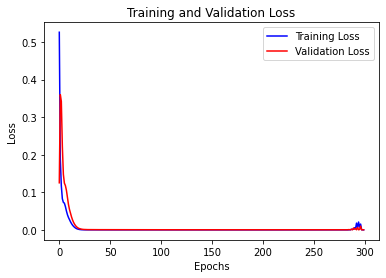

```
Validation mean squared error of  LSTM  model: 46.749
Test mean squared error of  LSTM  model: 39.387
4. PREDICTION USING TEST SET WITH MODEL  LSTM
```

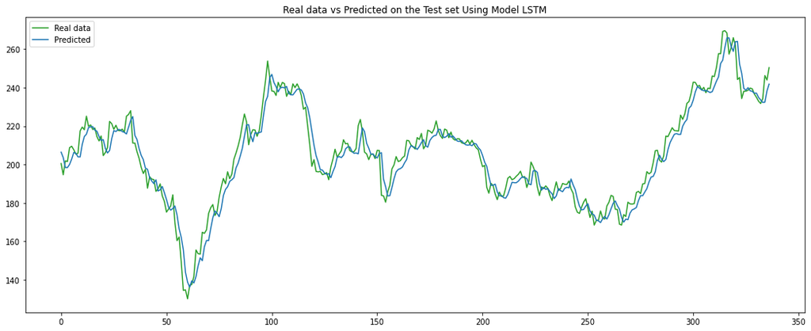

```python
def fn_build_model_lstm(p_optimizer,p_activation, p_loss, p_input_shape):
    print('2. BUILD LSTM MODEL')
    print('----------Optimizer:', p_optimizer)
    print('----------Activation: ',p_activation)
    print('----------Input shape: ', p_input_shape)
    print('----------Loss: ',p_loss)

    model = Sequential()
    model.add(LSTM(units=50, activation=p_activation, input_shape=p_input_shape))
    model.add(Dense(1))

    model.compile(optimizer=p_optimizer, loss = p_loss)
    return model


def fn_display_history(history):
    history.history.keys()
    history_dict = history.history # the dictionary that has the information on loss and accuracy per epoch

    loss_values = history_dict['loss']   # training loss
    val_loss_values = history_dict['val_loss'] # validation loss

    plt.plot(history.history['loss'], 'b', label="Training Loss")
    plt.plot(history.history['val_loss'], 'r', label="Validation Loss")
    plt.title("Training and Validation Loss")
    plt.xlabel("Epochs")
    plt.ylabel("Loss")
    plt.legend()
    plt.show()
    return


def fn_train_model(p_modelname, model, x_train, y_train, x_val, y_val, x_test, y_test, p_epochs, p_batch_size, p_shuffle, p_verbose, scaler, p_silence=False, p_plot=True):
    if not(p_silence):
        print('3. MODEL TRAINING : ', p_modelname)

    start_time = time.time()
    history=model.fit(x_train, y_train, epochs=p_epochs, validation_data=(x_val, y_val), verbose=p_verbose, batch_size=p_batch_size, shuffle=p_shuffle)

    if not(p_silence):
        print('----------Total Training Time (second):', time.time() - start_time)
        fn_display_history(history)


    # Valiation dataset
    y_pred=model.predict(x_val)

    # invert scaling
    y_pred_inv = y_pred / scaler.scale_[0]
    y_inv = y_val / scaler.scale_[0]

    y_pred_inv=np.concatenate(y_pred_inv).ravel()
    y_inv=np.concatenate(y_inv).ravel()

    val_score = mean_squared_error(y_inv, y_pred_inv)
    if not(p_silence):
        print('Validation mean squared error of ',p_modelname,' model: %.3f' % val_score)

    # Test dataset
    y_pred=model.predict(x_test)

    # invert scaling
    y_pred_inv = y_pred / scaler.scale_[0]
    y_inv = y_test / scaler.scale_[0]

    y_pred_inv=np.concatenate(y_pred_inv).ravel()
    y_inv=np.concatenate(y_inv).ravel()

    test_score = mean_squared_error(y_inv, y_pred_inv)
    if not(p_silence):
        print('Test mean squared error of ',p_modelname,' model: %.3f' % test_score)


    if p_plot:
        if not(p_silence):
            print('4. PREDICTION USING TEST SET WITH MODEL ', p_modelname)
        plt.figure(figsize = (18,7))
        plt.title('Real data vs Predicted on the Test set Using Model '+p_modelname)
        plt.plot(y_inv, 'tab:green', label='Real data')
        plt.plot(y_pred_inv, 'tab:blue', label='Predicted')
        plt.legend()
        plt.show()

    return history, y_inv, y_pred_inv



def fn_lstm(data):
    print('================================================================================================================================')
    print('=                                                  LSTM MODEL                                                                  =')
    print('================================================================================================================================')

    n_pct_train,n_pct_val= fn_init()

    data_scaled, scaler = fn_scale_data(df=data)

    n_look_back=7
    n_predict_day=1
    X, Y = fn_build_data_XY(df=data_scaled, p_look_back=n_look_back, p_predict_day=n_predict_day)

    x_train, y_train, x_val, y_val, x_test, y_test=fn_split_data(p_X=X, p_Y=Y, p_pct_train=n_pct_train, p_pct_val=n_pct_val)
    print('data.shape:',data.shape)
    print('x_train.shape:',x_train.shape, 'y_train.shape: ',y_train.shape)
    print('x_test.shape:',x_test.shape, 'y_test.shape: ',y_test.shape)
    print('x_val.shape:',x_val.shape, 'y_val.shape: ', y_val.shape)


    p_modelname='LSTM'
    p_activation = 'sigmoid'
    p_optimizer='adam'
    p_loss = 'mean_squared_error'
    p_input_shape = (x_train.shape[1], x_train.shape[2])
    model = fn_build_model_lstm(p_optimizer,p_activation, p_loss, p_input_shape)

    p_batch_size = 128
    p_shuffle = False
    p_epochs=300
    p_verbose=2
    history, y_inv, y_pred_inv=fn_train_model(p_modelname, model,  x_train, y_train, x_val, y_val, x_test, y_test, p_epochs, p_batch_size, p_shuffle, p_verbose ,scaler)

    test_score = mean_squared_error(y_inv, y_pred_inv)
    return test_score

test_score=fn_lstm(data)

# store to compare with other models
result={'model':['LSTM'],'test_score':[test_score]}
df_score=df_score.append(pd.DataFrame(result),ignore_index=True)
```

```python
type(data)
```

```
pandas.core.frame.DataFrame
```

#### LSTM Model (realtime data)

```
++++++++++ LOAD DATA REALTIME +++++++++
================================================================================================================================
=                                                  LSTM MODEL                                                                  =
================================================================================================================================
1. Build X and y dataset that are input and target Variables
----------X dataset has sequences of date that is date series and all features
----------Y dataset has sequences of date that is date series and the feature "CLOSE"
----------The number of recent days to look back in order to predict the next day: 7
----------The number of predict day: 1
data.shape: (1260, 6)
x_train.shape: (876, 7, 6) y_train.shape:  (876, 1, 1)
x_test.shape: (251, 7, 6) y_test.shape:  (251, 1, 1)
x_val.shape: (125, 7, 6) y_val.shape:  (125, 1, 1)
2. BUILD LSTM MODEL
----------Optimizer: adam
----------Activation:  sigmoid
----------Input shape:  (7, 6)
----------Loss:  mean_squared_error
3. MODEL TRAINING :  LSTM
----------Total Training Time (second): 13.729488849639893
```

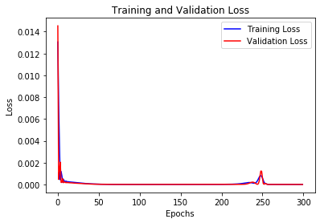

```
Validation mean squared error of  LSTM  model: 3.206
Test mean squared error of  LSTM  model: 477.539
4. PREDICTION USING TEST SET WITH MODEL  LSTM
```

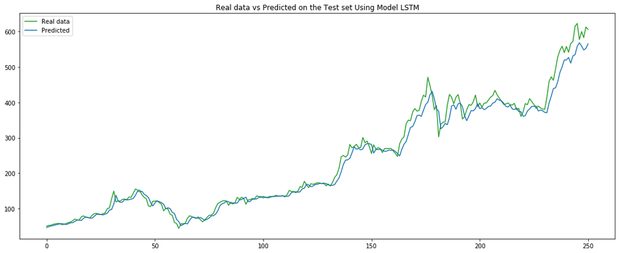

```python
print('++++++++++ LOAD DATA REALTIME +++++++++')
p_realtime=1
p_year = 5
data_realtime, data_realtime_raw = fn_load_data(p_realtime,p_stockname,p_year)

test_score=fn_lstm(data_realtime)

# store to compare with other models
result={'model':['LSTM (realtime data)'],'test_score':[test_score]}
df_score=df_score.append(pd.DataFrame(result),ignore_index=True)
```

#### MLP Model

```
================================================================================================================================
=                                                  MLP                                                                         =
================================================================================================================================
data.shape: (1692, 6)
x_train.shape: (1184, 6) y_train.shape:  (1184, 1)
x_test.shape: (339, 6) y_test.shape:  (339, 1)
x_val.shape: (169, 6) y_val.shape:  (169, 1)
2. BUILD MLP MODEL
----------Optimizer: adam
----------Activation:  relu
----------Loss:  mean_squared_error
3. MODEL TRAINING :  MLP
----------Total Training Time (second): 4.206667423248291
```

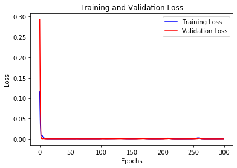

```
Validation mean squared error of  MLP  model: 6.930
Test mean squared error of  MLP  model: 5.620
4. PREDICTION USING TEST SET WITH MODEL  MLP
```

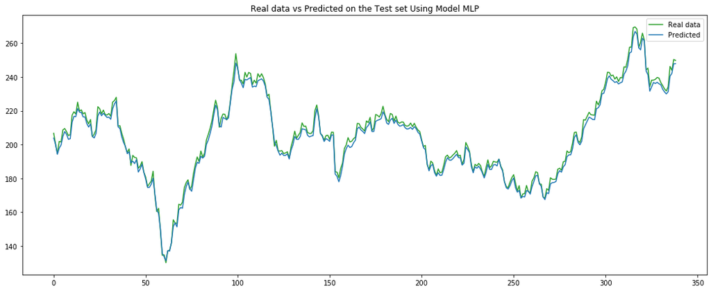

```python
def fn_build_model_mlp(p_optimizer,p_activation, p_loss, p_silence=False):
    if not(p_silence):
        print('2. BUILD MLP MODEL')
        print('----------Optimizer:', p_optimizer)
        print('----------Activation: ',p_activation)
        print('----------Loss: ',p_loss)

    model = Sequential()
    model.add(Dense(100, activation=p_activation))
    model.add(Dense(1))

    model.compile(optimizer=p_optimizer, loss = p_loss)
    return model

def fn_MLP(data, p_silence=False):
    if not(p_silence):
        print('================================================================================================================================')
        print('=                                                  MLP                                                                         =')
        print('================================================================================================================================')

    n_pct_train,n_pct_val= fn_init()

    data_scaled, scaler = fn_scale_data(df=data)


    X=data_scaled # if take all but last column, use X=data_scaled[:,-:1]
    Y=data_scaled[:,-1:] # last column which is 'Close'

    x_train, y_train, x_val, y_val, x_test, y_test=fn_split_data(p_X=X, p_Y=Y, p_pct_train=n_pct_train, p_pct_val=n_pct_val)
    if not(p_silence):
        print('data.shape:',data.shape)
        print('x_train.shape:',x_train.shape, 'y_train.shape: ',y_train.shape)
        print('x_test.shape:',x_test.shape, 'y_test.shape: ',y_test.shape)
        print('x_val.shape:',x_val.shape, 'y_val.shape: ', y_val.shape)


    p_modelname='MLP'
    p_activation = 'relu'
    p_optimizer='adam'
    p_loss = 'mean_squared_error'
    # p_input_shape = (x_train.shape[1],1) #(x_train.shape[1], x_train.shape[2])
    model = fn_build_model_mlp(p_optimizer,p_activation, p_loss)

    p_batch_size = 128
    p_shuffle = False
    p_epochs=300
    p_verbose=0
    history, y_inv, y_pred_inv = fn_train_model(p_modelname, model,  x_train, y_train, x_val, y_val, x_test, y_test, p_epochs, p_batch_size, p_shuffle, p_verbose ,scaler)
    test_score = mean_squared_error(y_inv, y_pred_inv)
    return test_score

test_score=fn_MLP(data)

# store to compare with other models
result={'model':['MLP'],'test_score':[test_score]}
df_score=df_score.append(pd.DataFrame(result),ignore_index=True)
```

#### ARIMA Model

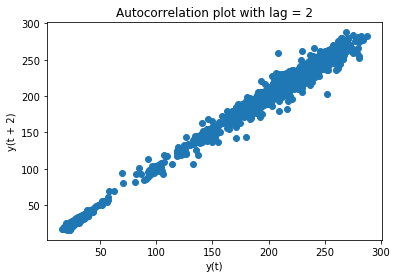

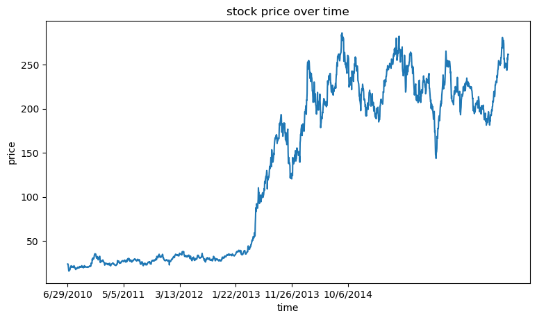

```
Testing Mean Squared Error 36.480159893643204
```

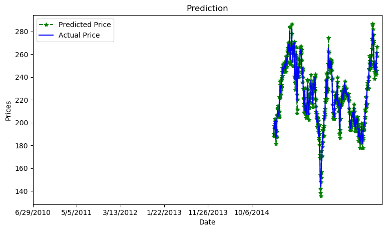

```python
from pandas.plotting import lag_plot
data2 = pd.read_csv('Tesla.csv')

plt.figure()
lag_plot(data2['Open'], lag=2)
plt.title('Autocorrelation plot with lag = 2')
plt.show()

plt.figure(figsize=(9,5), dpi=100)
plt.plot(data2['Date'],data2['Close'])

plt.xticks(np.arange(0,1200, 215), data2['Date'][0:1200:215])
plt.title("stock price over time")
plt.xlabel("time")
plt.ylabel("price")
plt.show()



train_data, test_data = data2[0:int(len(data2)*0.7)], data2[int(len(data2)*0.7):]
training_data = train_data['Close'].values
test_data = test_data['Close'].values
history = [x for x in training_data]
model_predictions = []
N_test_observations = len(test_data)
for time_point in range(N_test_observations):
    model = ARIMA(history, order=(3,2,0))
    model_fitted = model.fit(disp=0)
    output = model_fitted.forecast()
    ypred = output[0]
    model_predictions.append(ypred)
    true_test_value = test_data[time_point]
    history.append(true_test_value)
MSE_error = mean_squared_error(test_data, model_predictions)
print('Testing Mean Squared Error {}'.format(MSE_error))


test_set_range = data2[int(len(data2)*0.7):].index
plt.figure(figsize=(9,5), dpi=100)
plt.plot(test_set_range, model_predictions, color='green', marker='*', linestyle='dashed',label='Predicted Price')
plt.plot(test_set_range, test_data, color='blue', label='Actual Price')
plt.xticks(np.arange(0,1200,215), data2.Date[0:1200:215])
plt.title('Prediction')
plt.xlabel('Date')
plt.ylabel('Prices')

plt.legend()
plt.show()
```

#### SVM Model

```python
# # regressor_svr = SVR(kernel='rbf', degree=3, gamma='scale',  C=1.0, epsilon=0.1, max_iter=-1)
# # regressor_svr.fit(x_train[:,:,0],y_train[:,:,0])
# # y_pred_svr = regressor_svr.predict(x_test[:,:,0])

# # grid = np.arange(min(y_pred_svr),max(y_pred_svr), 0.01)
# # grid =grid.reshape(len(grid),1)
# # print('score: ', ((regressor_svr.score(x_train[:,:,0],y_train[:,:,0]))*100))

# # plt.scatter(y_test[:,:,0],y_pred_svr,color ='blue')
# # plt.plot(grid, grid, color ='red')
# # plt.title('Truth or Bluff(SVR)')
# # plt.xlabel('Open')
# # plt.ylabel('Close')
# # plt.show()
# # #print()


# def fn_fitmodel(modelobj, X_train, y_train, X_test, y_test):
#     startdt = datetime.now()
#     print("Start Time:", startdt.strftime("%H:%M:%S"), ",",date.today())
#     modelobj.fit(X_train,y_train)
#     y_pred = modelobj.predict(X_test)
#     y_pred_train = modelobj.predict(X_train)
#     enddt = datetime.now()
#     print("End Time:", enddt.strftime("%H:%M:%S"), ",",date.today())
#     return y_pred, y_pred_train

# def fn_evaluatemodel(df_acc,p_model, y_train,y_pred_train_lr,y_test,y_pred_lr):
#     print('The Coefficients: \n', lr.coef_)
#     print('Intercept: \n', lr.intercept_)

#     #R.M.S.E (Root Mean Squared Error)
#     rmse_train= np.sqrt(mean_squared_error(y_train,y_pred_train_lr))
#     rmse_test = np.sqrt(mean_squared_error(y_test,y_pred_lr))
#     print('Mean squared error (Train): %.2f' % rmse_train)
#     print('Mean squared error (Test): %.2f' % rmse_test)
#     if (rmse_train>1)|(rmse_test>1)|(rmse_train<-1)|(rmse_test<-1) :
#         rmse_train=0
#         rmse_test =0

#     #R.M.S.L.E (Root Mean Squared Log Error)
#     rmsle_train= np.sqrt(mean_squared_log_error(y_train,y_pred_train_lr))
#     rmsle_test = np.sqrt(mean_squared_log_error( y_test,y_pred_lr))
#     print('Root Mean Squared Log Error (Train): %.2f' % rmsle_train)
#     print('Root Mean Squared Log Error (Test): %.2f' % rmsle_test)

#     #R-Squared evaluation technique
#     r2_train=r2_score(y_train,y_pred_train_lr)
#     r2_test=r2_score(y_test,y_pred_lr)
#     print('R-Squared (Train): %.2f' % r2_train)
#     print('R-Squared (Test): %.2f' % r2_test)

#     # add results of accuracy to plot later
#     result={'model':[p_model],'rmse_train':[rmse_train],'rmse_test':[rmse_test],'rmsle_train':[rmsle_train],'rmsle_test':[rmsle_test], 'r2_train':[r2_train],'r2_test':[r2_test]}
#     df_acc = df_acc.append(pd.DataFrame(result),ignore_index=True)
#     return df_acc


# X=data2.drop(['Revenue','State','Timeframe','Type','Date','AveragePrice','Total_Volume'],axis=1)
# X
# Y=data2.Revenue
# Y

# scaler = MinMaxScaler()
# scaler.fit(X)
# X_scaled=scaler.transform(X)

# p_testsize=0.2
# X_train, X_test, y_train, y_test = train_test_split(X_scaled, Y, test_size=p_testsize, random_state=p_randomstate)
# p_model="SVR"
# svr = SVR(kernel='linear',C=1)
# y_pred, y_pred_train = fn_fitmodel(svr, X_train, y_train, X_test, y_test)
# df_acc=fn_evaluatemodel(df_acc,p_model, y_train,y_pred_train,y_test,y_pred)
```

#### MLP is the best model among MLP, Persistence, and LSTM models because it has got the lowest "mean square error"

```python
# score of models
df_score.sort_values(by=['test_score'])

# the best model is MLP
```

[output not shown]

#### APPLY MLP MODEL FOR 10 OTHER STOCKS

```python
print('++++++++++ LOAD DATA +++++++++')
def fn_load_data_list(realtime, p_stockNameList, p_year=2):
    if (realtime==1):
        # Read data online from remote source
        enddate = datetime.now()
        startdate = datetime(enddate.year - p_year, enddate.month, enddate.day)
        data_raw=DataReader(p_stockName, 'yahoo', startdate, enddate)
    else:
        data_raw = pd.read_csv('prices.csv', encoding= 'ISO-8859-1', index_col='date', parse_dates=['date'])
    # make a copy dataframe for working
    data=data_raw.copy()
    return data, data_raw

p_realtime=0
p_stocklist=['AAP', 'AAL', 'AAPL', 'BAC', 'BAX', 'BA', 'CA', 'CAH', 'CAG', 'DAL']
p_year=2
data_full, data_full_raw = fn_load_data_list(p_realtime,p_stocklist)
print("Raw Data.shape:",data.shape)

print("Raw Data.info:")
print(data_full_raw.info())
```

```
++++++++++ LOAD DATA +++++++++
Raw Data.shape: (1692, 6)
Raw Data.info:
<class 'pandas.core.frame.DataFrame'>
DatetimeIndex: 10080 entries, 2014-01-02 to NaT
Data columns (total 6 columns):
 #   Column  Non-Null Count  Dtype
---  ------  --------------  -----
 0   symbol  7560 non-null   object
 1   open    7560 non-null   float64
 2   close   7560 non-null   float64
 3   low     7560 non-null   float64
 4   high    7560 non-null   float64
 5   volume  7560 non-null   float64
dtypes: float64(5), object(1)
memory usage: 551.2+ KB
None
```

```python
def fn_process_stock(data):
    n_pct_train,n_pct_val= fn_init()

    data_scaled, scaler = fn_scale_data(df=data)


    X=data_scaled # if take all but last column, use X=data_scaled[:,-:1]
    Y=data_scaled[:,-1:] # last column which is 'Close'

    x_train, y_train, x_val, y_val, x_test, y_test=fn_split_data(p_X=X, p_Y=Y, p_pct_train=n_pct_train, p_pct_val=n_pct_val)

    p_modelname='MLP'
    p_activation = 'relu'
    p_optimizer='adam'
    p_loss = 'mean_squared_error'

    model = fn_build_model_mlp(p_optimizer,p_activation, p_loss,p_silence=True)

    p_batch_size = 128
    p_shuffle = False
    p_epochs=300
    p_verbose=0
    history, y_inv, y_pred_inv=fn_train_model(p_modelname, model,  x_train, y_train, x_val, y_val, x_test, y_test, p_epochs, p_batch_size, p_shuffle, p_verbose ,scaler, p_silence=True, p_plot=False)
    return history, y_inv, y_pred_inv
```

```python
df_loss=pd.DataFrame()
df_mse=pd.DataFrame()

for idx, stock in enumerate(p_stocklist):
    print('[',idx+1,'/',len(p_stocklist),'] processing stock ',stock,'...')

    start_time = time.time()

    data_stock=data_full[data_full['symbol']==stock]
    data_stock.drop(columns='symbol',inplace=True)


    h, yi, ypi=fn_process_stock(data_stock)


    test_score = mean_squared_error(yi, ypi)
    result={'stock':[stock],'test_score':[test_score]}
    df_mse=df_mse.append(pd.DataFrame(result),ignore_index=True)


    result={'stock':[stock],'mean_loss':[h.history['val_loss']],'processing_time':[time.time()-start_time]}
    df_loss=df_loss.append(pd.DataFrame(result),ignore_index=True)

print("Done")
```

```
[ 1 / 10 ] processing stock  AAP ...
[ 2 / 10 ] processing stock  AAL ...
[ 3 / 10 ] processing stock  AAPL ...
[ 4 / 10 ] processing stock  BAC ...
[ 5 / 10 ] processing stock  BAX ...
[ 6 / 10 ] processing stock  BA ...
[ 7 / 10 ] processing stock  CA ...
[ 8 / 10 ] processing stock  CAH ...
[ 9 / 10 ] processing stock  CAG ...
[ 10 / 10 ] processing stock  DAL ...
Done
```

```python
df_mse
```

|  | stock | test_score |
| --- | --- | --- |
| 0 | AAP | 0.006486 |
| 1 | AAL | 0.007903 |
| 2 | AAPL | 0.817808 |
| 3 | BAC | 0.001890 |
| 4 | BAX | 0.059374 |
| 5 | BA | 0.011401 |
| 6 | CA | 0.000555 |
| 7 | CAH | 0.006033 |
| 8 | CAG | 0.004333 |
| 9 | DAL | 0.001059 |

#### Visualiz the loss series in training phase of 10 other stocks by MLP

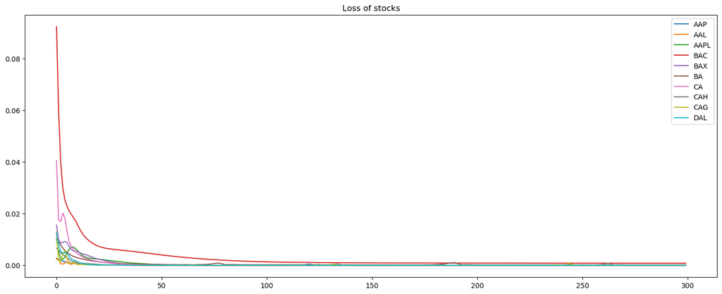

```python
plt.figure(figsize=(18,7), dpi=100)
plt.title('Loss of stocks')

for idx,stock in enumerate(df_loss['stock']):
    plt.plot(df_loss['mean_loss'][idx], label=df_loss['stock'][idx])

plt.legend()
plt.show()
```

#### Re-visualize the last 200 loss series in training phase of 10 other stocks by MLP for easy view

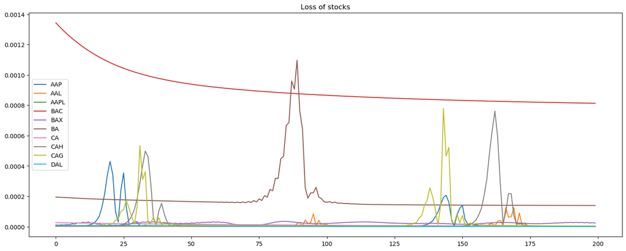

```python
# just display the last 100 loss records
plt.figure(figsize=(18,7), dpi=100)
plt.title('Loss of stocks')

for idx,stock in enumerate(df_loss['stock']):
    plt.plot(df_loss['mean_loss'][idx][-200:], label=df_loss['stock'][idx])
#     print(type(df_loss['mean_loss'][idx]))

plt.legend()
plt.show()
```